# Figure 2: Single-nucleus RNA-seq of AD vs AD+LBP superior frontal gyrus

felix.struebing@med.uni-muenchen.de

2026-07-09

This notebook documents the single-nucleus RNA-seq analyses used for manuscript Fig. 2a-h. It starts from a precomputed annotated Seurat object and reproduces the plotting and pseudobulk summaries used in the figure.

# 1 Libraries

```r
library(Seurat)
library(tidyverse)
library(tidyseurat)
library(data.table)
library(patchwork)
library(edgeR)
source('resources/ggplot_theme_FLS.R')
snmn     <- '/home/fstruebi/projects/SNCA_MAPT_network'
multiome <- '/home/fstruebi/projects/multiome'
```

# 2 Load annotated Seurat object

Load the merged, SCTransform-normalised, MAGIC-imputed snRNA-seq dataset with the final cluster labels used in the manuscript.

```r
seurat <- readRDS(file.path(snmn, 'export/seurat_SCT_MAGIC_annotated_final.rds'))
DefaultAssay(seurat) <- 'RNA'
seurat$cell <- colnames(seurat)
table(seurat$final_cluster_lvl2)
```

```
##
## Astro  Ex_1 Ex_10  Ex_2  Ex_3  Ex_4  Ex_5  Ex_6  Ex_7  Ex_8  Ex_9 Inh_1 Inh_2
##  2268  4684   114  2205  2162  1117   525   339   335   330   242  2222  1772
## Inh_3 Inh_4 Inh_5 Inh_6 Inh_7 MiGli    NA Oligo   OPC  Vasc
##   987   594   377   325   203   346   110  2421  1160   306
```

# 3 Cluster colours and QC-passing cells

`final_clusters` maps the 23 Seurat clusters onto the annotated level-2 labels and supplies a stable colour per cluster.

```r
final_clusters <- seurat %>%
    mutate(final_cluster_lvl1 = case_when(
        seurat_clusters %in% c(4, 14, 5, 0, 8, 21, 11, 19, 15, 16) ~ 'Ex',
        seurat_clusters %in% c(10, 3, 17, 6, 20, 12, 9)            ~ 'Inh',
        seurat_clusters == 18 ~ 'Vasc',
        seurat_clusters == 13 ~ 'MiGli',
        seurat_clusters == 1  ~ 'Oligo',
        seurat_clusters == 2  ~ 'Astro',
        seurat_clusters == 7  ~ 'OPC',
        TRUE ~ NA_character_
    )) %>%
    group_by(final_cluster_lvl1, seurat_clusters) %>%
    tally() %>%
    mutate(id = row_number(),
           final_cluster_lvl2 = paste0(final_cluster_lvl1, '_', id)) %>%
    ungroup() %>%
    group_by(final_cluster_lvl1) %>%
    add_count(name = 'nn') %>%
    mutate(final_cluster_lvl2 = ifelse(nn == 1,
                                       str_sub(final_cluster_lvl2, end = -3L),
                                       final_cluster_lvl2))
```

```r
library(scCustomize)
p <- DiscretePalette_scCustomize(num_colors = 40, palette = 'varibow')
clustercolors <- c(p[7], p[10:20], p[21:26], p[31], p[34], p[4], p[40])
names(clustercolors) <- final_clusters %>%
    filter(final_cluster_lvl1 != 'NA') %>%
    pull(final_cluster_lvl2)
ann_colors <- list(cluster = clustercolors)
```

```r
seurat_subs <- seurat
```

# 4 Fig. 2a — UMAP of annotated clusters

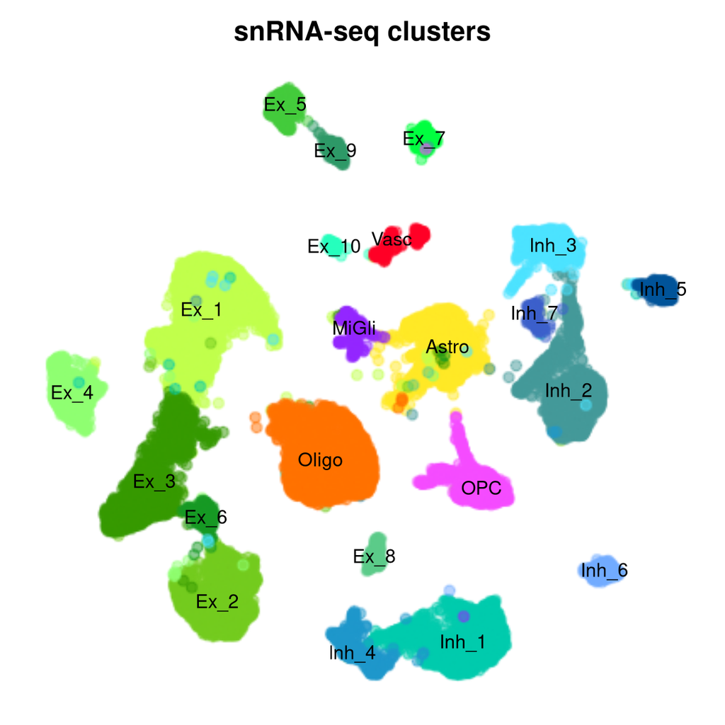

```r
p2a <- DimPlot(seurat_subs, group.by = 'final_cluster_lvl2',
               pt.size = 2, alpha = 0.5, raster = TRUE, label = TRUE, order = TRUE) +
    scale_color_manual(values = clustercolors) +
    labs(title = 'snRNA-seq clusters') +
    NoLegend() +
    theme(axis.text = element_blank(), axis.title = element_blank(),
          axis.line = element_blank(), axis.ticks = element_blank())
p2a
```

```r
pdf('figure/Fig2a_UMAP.pdf', width = 6, height = 6)
p2a
dev.off()
```

# 5 Pseudobulk aggregation (cluster level)

Counts are aggregated per sample x cluster from the MAGIC-imputed assay, then treated as a pseudobulk `DGEList` for marker identification and MDS.

```r
useassay <- 'MAGIC_RNA'
s2pb <- function(object, sample, cluster = 'seurat_clusters') {
    counts <- SeuratObject::GetAssayData(object, assay = useassay, layer = 'data')
    meta   <- object@meta.data
    sp     <- meta[, sample]
    clst   <- meta[, cluster]
    genes  <- data.frame(gene = rownames(object[[useassay]]))
    genes  <- cbind(genes, object[[useassay]][[]])
    sp_clst <- factor(paste(sp, clst, sep = '_cluster'))
    group_mat <- Matrix::sparse.model.matrix(~ 0 + sp_clst)
    colnames(group_mat) <- gsub('^sp_clst', '', colnames(group_mat))
    counts.pb <- counts %*% group_mat
    sample.pb <- data.frame(sample  = gsub('_cluster.*$', '', levels(sp_clst)),
                            cluster = gsub('^.*_cluster', '', levels(sp_clst)))
    DGEList(counts = as.matrix(counts.pb), samples = sample.pb, genes = genes)
}

y <- s2pb(seurat_subs, sample = 'orig.ident', cluster = 'final_cluster_lvl2')
keep.genes <- filterByExpr(y, group = y$samples$cluster)
y <- y[keep.genes, , keep = FALSE]
y <- normLibSizes(y)
```

## 5.1 Fig. 2c — Pseudobulk MDS

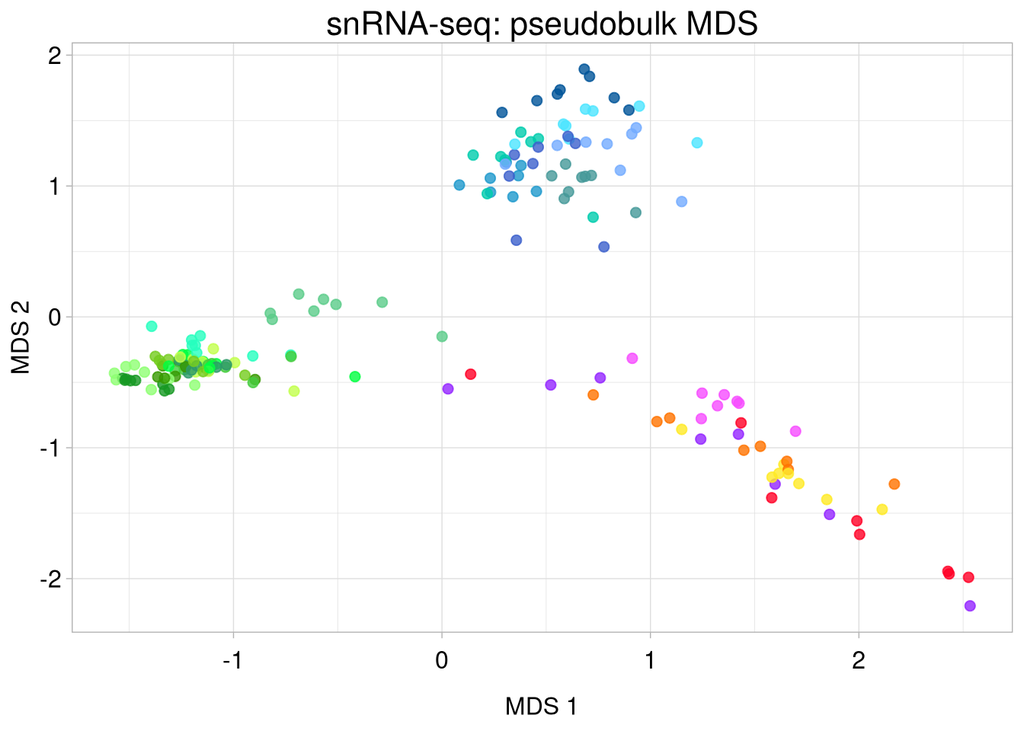

```r
cluster <- as.factor(y$samples$cluster)
mymds <- plotMDS(y, plot = FALSE)
p2c <- data.frame(x = mymds$x, y = mymds$y, cluster = cluster) %>%
    ggplot(aes(x = x, y = y, color = cluster)) +
    geom_point(size = 2, alpha = 0.8) +
    scale_color_manual(values = clustercolors, guide = 'none') +
    labs(x = 'MDS 1', y = 'MDS 2', title = 'snRNA-seq: pseudobulk MDS') +
    theme_FLS()
p2c
```

## 5.2 Marker gene identification

Each cluster is contrasted against the average of all others (donor included as a blocking factor) to obtain cluster marker genes.

```r
donor  <- factor(y$samples$sample)
design <- model.matrix(~ cluster + donor)
colnames(design) <- gsub('donor', '', colnames(design))
colnames(design)[1] <- 'Intercept'

y   <- estimateDisp(y, design, robust = TRUE)
fit <- glmQLFit(y, design, robust = TRUE)

ncls  <- nlevels(cluster)
contr <- rbind(matrix(1 / (1 - ncls), ncls, ncls),
               matrix(0, ncol(design) - ncls, ncls))
diag(contr) <- 1
contr[1, ] <- 0
rownames(contr) <- colnames(design)
colnames(contr) <- paste0('cluster', levels(cluster))

qlf <- lapply(seq_len(ncls), function(i) {
    res <- glmQLFTest(fit, contrast = contr[, i])
    res$comparison <- paste0('cluster', levels(cluster)[i], '_vsOthers')
    res
})
```

```r
topMarkers <- lapply(qlf, function(x) {
    x$table %>% rownames_to_column('gene') %>% mutate(cluster = x$comparison)
}) %>%
    rbindlist() %>%
    filter(!grepl('^(AC|AL|AJ|AP|MT-|MSTRG\\.|LINC)', gene)) %>%
    group_by(cluster) %>%
    slice_min(PValue, n = 50) %>%
    slice_max(logFC, n = 3) %>%
    pull(gene) %>%
    unique()
```

## 5.3 Fig. 2b — Top marker gene heatmap

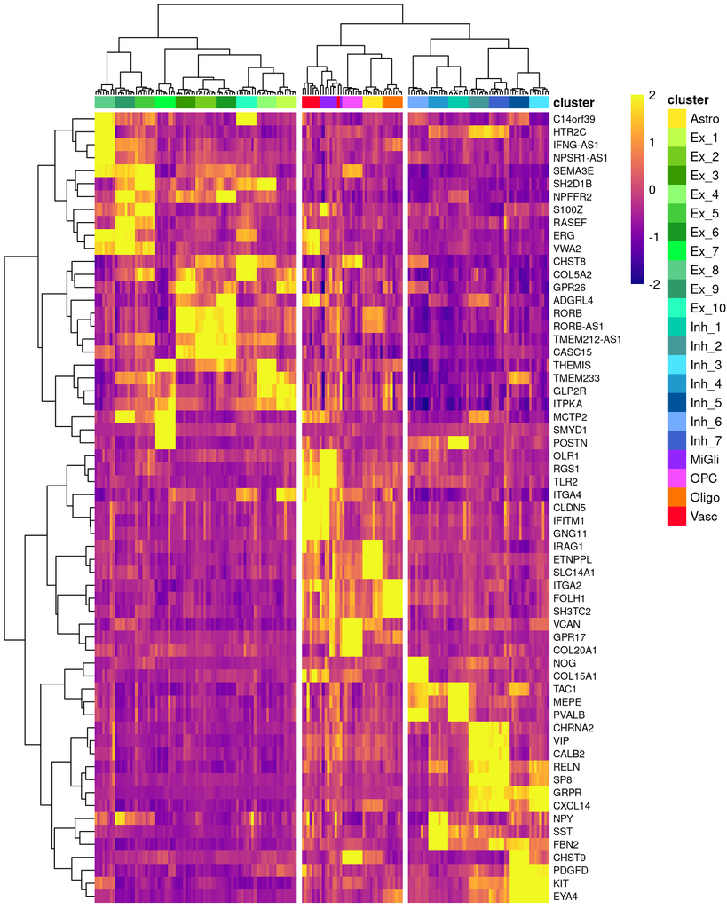

```r
library(pheatmap)
library(viridis)
lcpm  <- cpm(y, log = TRUE)
annot <- data.frame(cluster = factor(cluster))
rownames(annot) <- colnames(y)

p2b <- pheatmap::pheatmap(lcpm[topMarkers, ],
                          breaks = seq(-2, 2, length.out = 101),
                          color = viridis::plasma(100), scale = 'row',
                          cluster_cols = TRUE, border_color = 'NA',
                          fontsize_row = 8, treeheight_row = 70,
                          treeheight_col = 70, cutree_cols = 3,
                          clustering_method = 'ward.D2', show_colnames = FALSE,
                          annotation_col = annot, annotation_colors = ann_colors,
                          silent = TRUE)
plot(p2b[[4]])
```

```r
pdf('figure/Fig2b_marker_heatmap.pdf', width = 8, height = 10)
plot(p2b[[4]])
dev.off()
```

# 6 Differential expression: AD vs AD+LBP per cluster

DE is tested per cluster on RNA-assay pseudobulk aggregated by group, cluster, and donor using an edgeR quasi-likelihood F-test. The code below applies the manuscript thresholds of |log2FC| > 0.5 and FDR < 0.1.

```r
pseudobulk <- AggregateExpression(seurat_subs,
                                  group.by = c('group', 'final_cluster_lvl2', 'orig.ident'),
                                  return.seurat = TRUE, assay = 'RNA')
pb <- SplitObject(pseudobulk, split.by = 'final_cluster_lvl2')
pb <- lapply(pb, function(x) SeuratObject::GetAssayData(x, layer = 'counts'))

pb_res <- lapply(pb, function(x) {
    groupvec <- factor(str_extract(colnames(x), pattern = '[^_]*'))
    design   <- model.matrix(~ groupvec)
    yy <- DGEList(counts = x, group = groupvec)
    yy <- yy[filterByExpr(yy), , keep.lib.sizes = FALSE]
    yy <- normLibSizes(yy)
    fit <- glmQLFit(yy, design, robust = TRUE)
    q   <- glmQLFTest(fit, coef = 2)
    as_tibble(topTags(q, n = Inf)$table, rownames = 'gene')
})
de_all <- rbindlist(pb_res, idcol = 'cluster') %>% arrange(FDR)
de_all %>% filter(gene %in% c('MAPT', 'SNCA'))
```

```
##     cluster   gene        logFC   logCPM            F      PValue        FDR
##      <char> <char>        <num>    <num>        <num>       <num>      <num>
##  1:    Ex-7   MAPT  0.828672370 8.424315 1.010461e+01 0.003849984 0.07259318
##  2:    Ex-3   SNCA  0.383500406 8.679627 9.736352e+00 0.008288036 0.21426674
##  3:    Ex-1   SNCA  0.417220002 8.295695 6.552842e+00 0.024916195 0.29716878
##  4:   Inh-1   MAPT  0.309853527 8.044642 4.989239e+00 0.041884129 0.31571183
##  5:    Ex-4   MAPT  0.338509468 8.314815 4.598945e+00 0.048814724 0.33730400
##  6:    Ex-2   MAPT  0.364687837 8.214868 5.722907e+00 0.032317474 0.34251284
##  7:    Ex-5   MAPT  0.374103254 8.272356 3.839846e+00 0.063965122 0.34361264
##  8:    Ex-2   SNCA  0.268593148 8.624418 4.847355e+00 0.046086576 0.38257861
##  9:   Inh-4   SNCA  0.356269076 7.632879 3.692457e+00 0.071411065 0.42942940
## 10:    Ex-1   MAPT  0.306753038 8.348343 3.544534e+00 0.084068117 0.45565501
## 11:    Ex-3   MAPT  0.215044656 8.186905 3.007236e+00 0.106977937 0.46680368
## 12:   Inh-5   MAPT  0.376328436 8.343543 3.649302e+00 0.073878893 0.48813165
## 13:    Ex-8   SNCA  0.443694307 8.271179 3.132688e+00 0.093388834 0.55393710
```

[output cut: 32 more lines]

## 6.1 Fig. 2d — Distribution of DE genes per cluster

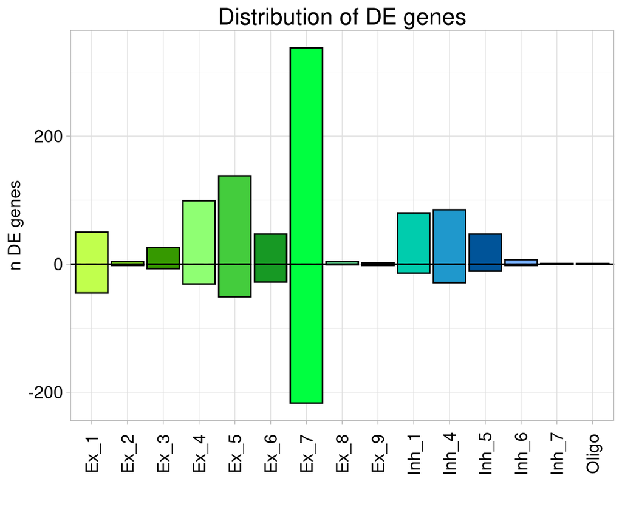

```r
de_distribution <- de_all %>%
    mutate(significant = ifelse(abs(logFC) > 0.5 & FDR < 0.1, 'yes', 'no'),
           direction = ifelse(logFC > 0, 'up', 'down')) %>%
    filter(significant == 'yes') %>%
    group_by(cluster, direction) %>%
    tally() %>%
    mutate(n = ifelse(direction == 'down', -n, n),
           cluster = str_replace(cluster, '-', '_'))

p2d <- de_distribution %>%
    ggplot(aes(x = n, y = cluster, fill = cluster)) +
    geom_col(color = 'black') +
    geom_vline(xintercept = 0, linetype = 5) +
    scale_fill_manual(values = clustercolors[names(clustercolors) %in% de_distribution$cluster],
                      guide = 'none') +
    labs(title = 'Distribution of DE genes', y = '', x = 'n DE genes') +
    coord_flip() +
    theme_FLS() +
    theme(axis.text.x = element_text(angle = 90))
p2d
```

```r
pdf('figure/Fig2d_DE_distribution.pdf', width = 6, height = 5)
p2d
dev.off()
```

# 7 Fig. 2e/f — Cluster-wise SNCA and MAPT expression

Group-level (AD vs AD+LBP) pseudobulk per cluster, plotted as logCPM heatmaps.

```r
DefaultAssay(seurat_subs) <- 'MAGIC_RNA'
yg <- Seurat2PB(seurat_subs, sample = 'group', cluster = 'final_cluster_lvl2')
yg <- yg[, yg$samples$lib.size > 5e4]
yg <- yg[filterByExpr(yg, group = yg$samples$cluster), , keep = FALSE]
yg <- normLibSizes(yg)
lcpm_g <- cpm(yg, log = TRUE)
```

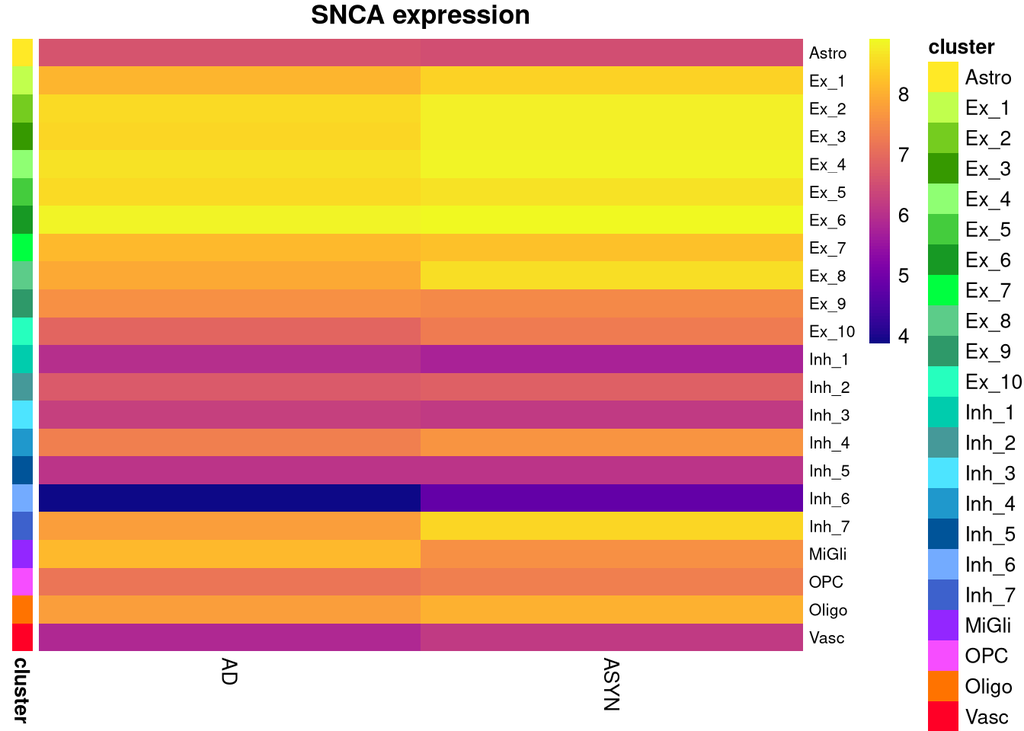

```r
library(ggplotify)

cluster_heatmap <- function(gene, title) {
    m <- as.data.frame(lcpm_g[gene, ]) %>%
        rownames_to_column() %>%
        separate(rowname, into = c('group', 'cluster', 'clusterno'), sep = '_') %>%
        mutate(cluster = str_sub(cluster, start = 8L),
               cluster = ifelse(is.na(clusterno), cluster,
                                paste0(cluster, '_', clusterno))) %>%
        dplyr::select(group, cluster, logCPM = 4) %>%
        pivot_wider(names_from = 'group', values_from = 'logCPM') %>%
        column_to_rownames('cluster')
    m <- m[names(clustercolors), , drop = FALSE]
    annot <- data.frame(cluster = rownames(m), row.names = rownames(m))
    as.ggplot(pheatmap::pheatmap(as.matrix(m), color = viridis::plasma(100),
                                 scale = 'none', cluster_cols = FALSE,
                                 cluster_rows = FALSE, border_color = 'NA',
                                 fontsize_row = 8, show_colnames = TRUE,
                                 annotation_row = annot,
                                 annotation_colors = ann_colors, main = title))
}

p2e <- cluster_heatmap('SNCA', 'SNCA expression')
```

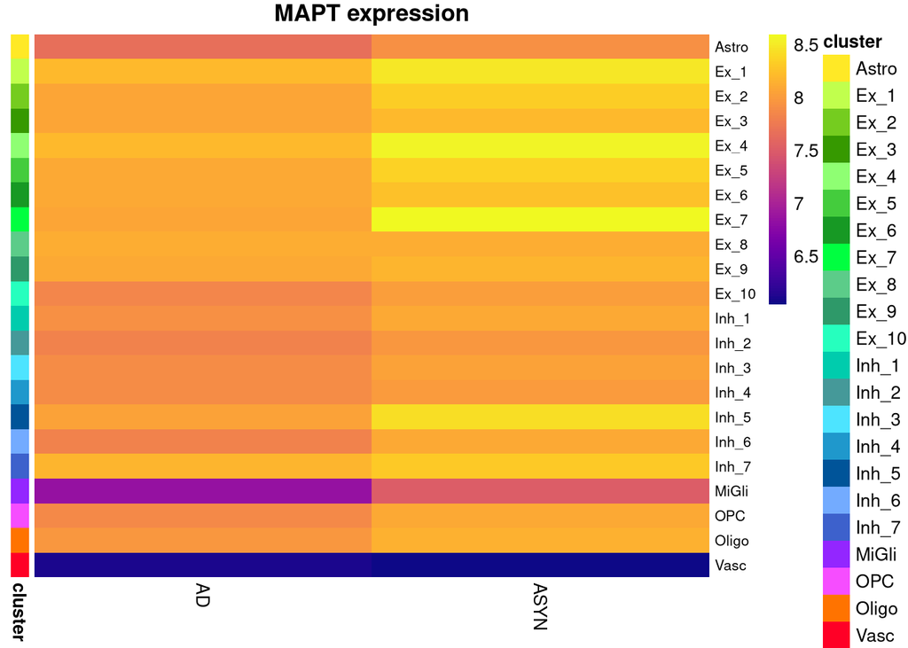

```r
p2f <- cluster_heatmap('MAPT', 'MAPT expression')
```

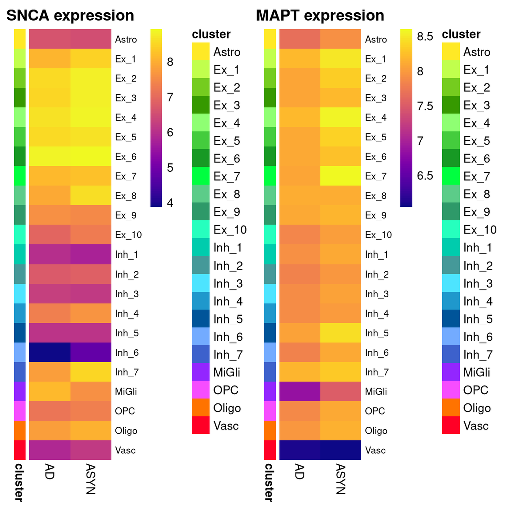

```r
p2e + p2f
```

```r
pdf('figure/Fig2ef_SNCA_MAPT_heatmaps.pdf', width = 6, height = 6)
p2e + p2f
dev.off()
```

# 8 Fig. 2g — Gene Ontology enrichment for cluster Ex-7

Load the precomputed enrichR results and plot the selected Ex-7 Gene Ontology terms used for Fig. 2g.

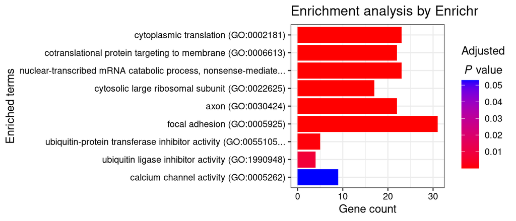

```r
de_enrichd <- readRDS(file.path(snmn, 'export/seurat_RNA_pb_DE_enriched.rds'))

p2g <- enrichR::plotEnrich(
    de_enrichd %>%
        filter(cluster == 'Ex-7') %>%
        filter(!Term %in% c('large ribosomal subunit (GO:0015934)',
                            'SRP-dependent cotranslational protein targeting to membrane (GO:0006614)',
                            'voltage-gated calcium channel activity (GO:0005245)')) %>%
        group_by(db) %>%
        slice_min(Adjusted.P.value, n = 3) %>%
        arrange(-Combined.Score),
    numChar = 60, orderBy = 'FDR', showTerms = 10)
p2g
```

```r
pdf('figure/Fig2g_Ex7_GO.pdf', width = 7, height = 2.5)
p2g
dev.off()
```

# 9 Fig. 2h — SNCA + MAPT co-expression

Calculate the per-cell co-expression score as the sum of normalised SNCA and MAPT counts, then fit a per-cluster linear model with diagnostic group.

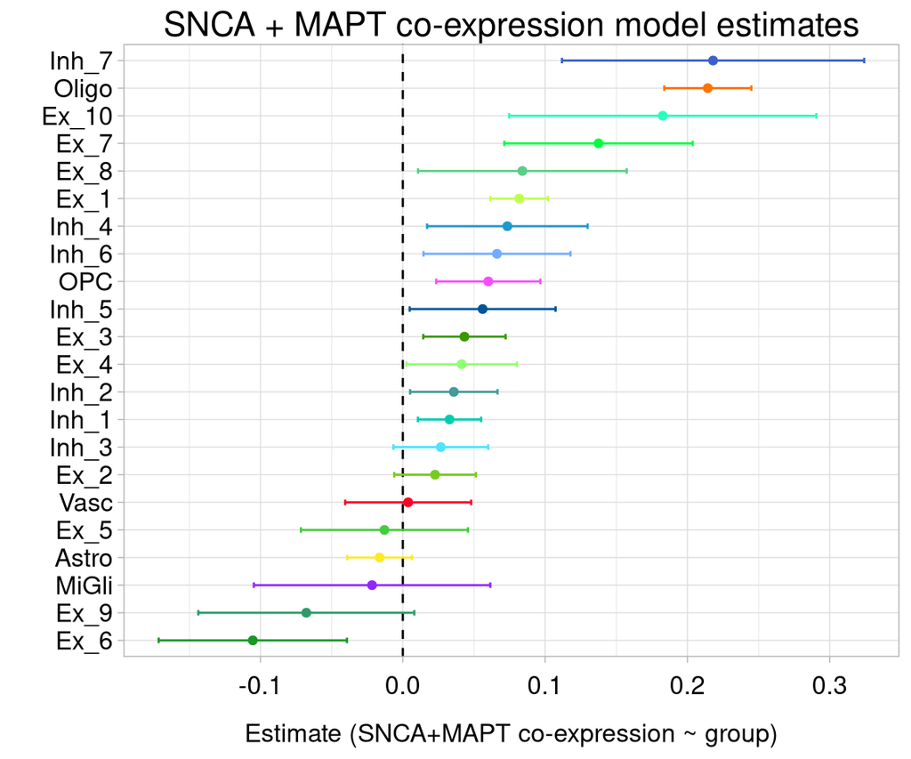

```r
library(broom)
DefaultAssay(seurat) <- 'SCT'

mycoex <- FetchData(seurat, vars = c('MAPT', 'SNCA')) %>%
    mutate(coex = MAPT + SNCA) %>%
    rownames_to_column('.cell') %>%
    left_join(as_tibble(seurat), by = '.cell') %>%
    group_by(final_cluster_lvl2) %>%
    nest() %>%
    mutate(fit = map(data, ~ lm(coex ~ group, data = .x)),
           tidy = map(fit, tidy)) %>%
    unnest(tidy) %>%
    dplyr::select(final_cluster_lvl2, term, std.error, estimate, p.value) %>%
    filter(term != '(Intercept)', final_cluster_lvl2 != 'NA') %>%
    arrange(p.value)

p2h <- mycoex %>%
    ggplot(aes(x = reorder(final_cluster_lvl2, estimate), y = estimate,
               ymin = estimate - std.error, ymax = estimate + std.error,
               color = final_cluster_lvl2)) +
    geom_hline(yintercept = 0, linetype = 'dashed') +
    geom_point() +
    geom_errorbar(width = 0.2) +
    scale_color_manual(values = clustercolors, guide = 'none') +
    coord_flip() +
    labs(x = '', y = 'Estimate (SNCA+MAPT co-expression ~ group)',
         title = 'SNCA + MAPT co-expression model estimates') +
    theme_FLS()
p2h
```

```r
pdf('figure/Fig2h_coexpression.pdf', width = 6, height = 4)
p2h
dev.off()
```